# Risk Factor Analysis

## Outcome Variable

**Outcome Variable:** whz

## Predictor Variables

**Intervention Variable:** perdiar6

**Adjustment Set:**

- arm
- sex
- W_mage
- meducyrs
- feducyrs
- hhwealth_quart
- hfoodsec
- W_mhtcm
- W_mwtkg
- W_mbmi
- W_birthwt
- W_birthlen
- W_nrooms
- month
- brthmon
- impfloor
- impsan
- safeh20
- delta_W_mage
- delta_meducyrs
- delta_feducyrs
- delta_hhwealth_quart
- delta_hfoodsec
- delta_W_mhtcm
- delta_W_mwtkg
- delta_W_mbmi
- delta_W_birthwt
- delta_W_birthlen
- delta_W_nrooms
- delta_month
- delta_brthmon
- delta_impfloor
- delta_impsan
- delta_safeh20

## Stratifying Variables

The analysis was stratified on these variable(s):

- agecat
- studyid
- country

## Data Summary

| agecat | studyid | country | perdiar6 | n_cell | n |
| --- | --- | --- | --- | --- | --- |
| Birth | ki0047075b-MAL-ED | BANGLADESH | 0% | 65 | 215 |
| Birth | ki0047075b-MAL-ED | BANGLADESH | (0%, 5%] | 86 | 215 |
| Birth | ki0047075b-MAL-ED | BANGLADESH | >5% | 64 | 215 |
| Birth | ki0047075b-MAL-ED | BRAZIL | 0% | 54 | 62 |
| Birth | ki0047075b-MAL-ED | BRAZIL | (0%, 5%] | 6 | 62 |
| Birth | ki0047075b-MAL-ED | BRAZIL | >5% | 2 | 62 |
| Birth | ki0047075b-MAL-ED | INDIA | 0% | 11 | 45 |
| Birth | ki0047075b-MAL-ED | INDIA | (0%, 5%] | 23 | 45 |
| Birth | ki0047075b-MAL-ED | INDIA | >5% | 11 | 45 |
| Birth | ki0047075b-MAL-ED | NEPAL | 0% | 8 | 26 |
| Birth | ki0047075b-MAL-ED | NEPAL | (0%, 5%] | 10 | 26 |
| Birth | ki0047075b-MAL-ED | NEPAL | >5% | 8 | 26 |
| Birth | ki0047075b-MAL-ED | PERU | 0% | 67 | 228 |
| Birth | ki0047075b-MAL-ED | PERU | (0%, 5%] | 69 | 228 |
| Birth | ki0047075b-MAL-ED | PERU | >5% | 92 | 228 |
| Birth | ki0047075b-MAL-ED | SOUTH AFRICA | 0% | 85 | 112 |
| Birth | ki0047075b-MAL-ED | SOUTH AFRICA | (0%, 5%] | 23 | 112 |
| Birth | ki0047075b-MAL-ED | SOUTH AFRICA | >5% | 4 | 112 |
| Birth | ki0047075b-MAL-ED | TANZANIA, UNITED REPUBLIC OF | 0% | 51 | 115 |
| Birth | ki0047075b-MAL-ED | TANZANIA, UNITED REPUBLIC OF | (0%, 5%] | 44 | 115 |
| Birth | ki0047075b-MAL-ED | TANZANIA, UNITED REPUBLIC OF | >5% | 20 | 115 |
| Birth | ki1000109-EE | PAKISTAN | 0% | 164 | 177 |
| Birth | ki1000109-EE | PAKISTAN | (0%, 5%] | 11 | 177 |
| Birth | ki1000109-EE | PAKISTAN | >5% | 2 | 177 |
| Birth | ki1017093-NIH-Birth | BANGLADESH | 0% | 150 | 572 |
| Birth | ki1017093-NIH-Birth | BANGLADESH | (0%, 5%] | 171 | 572 |
| Birth | ki1017093-NIH-Birth | BANGLADESH | >5% | 251 | 572 |
| Birth | ki1017093b-PROVIDE | BANGLADESH | 0% | 160 | 532 |
| Birth | ki1017093b-PROVIDE | BANGLADESH | (0%, 5%] | 206 | 532 |
| Birth | ki1017093b-PROVIDE | BANGLADESH | >5% | 166 | 532 |

[output cut: 87 more lines]

The following strata were considered:

- agecat: 24 months, studyid: ki0047075b-MAL-ED, country: BANGLADESH
- agecat: 24 months, studyid: ki0047075b-MAL-ED, country: BRAZIL
- agecat: 24 months, studyid: ki0047075b-MAL-ED, country: INDIA
- agecat: 24 months, studyid: ki0047075b-MAL-ED, country: NEPAL
- agecat: 24 months, studyid: ki0047075b-MAL-ED, country: PERU
- agecat: 24 months, studyid: ki0047075b-MAL-ED, country: SOUTH AFRICA
- agecat: 24 months, studyid: ki0047075b-MAL-ED, country: TANZANIA, UNITED REPUBLIC OF
- agecat: 24 months, studyid: ki1000109-EE, country: PAKISTAN
- agecat: 24 months, studyid: ki1017093-NIH-Birth, country: BANGLADESH
- agecat: 24 months, studyid: ki1017093b-PROVIDE, country: BANGLADESH
- agecat: 24 months, studyid: ki1017093c-NIH-Crypto, country: BANGLADESH
- agecat: 24 months, studyid: ki1114097-CMIN, country: BANGLADESH
- agecat: 24 months, studyid: ki1114097-CONTENT, country: PERU
- agecat: 6 months, studyid: ki0047075b-MAL-ED, country: BANGLADESH
- agecat: 6 months, studyid: ki0047075b-MAL-ED, country: BRAZIL
- agecat: 6 months, studyid: ki0047075b-MAL-ED, country: INDIA
- agecat: 6 months, studyid: ki0047075b-MAL-ED, country: NEPAL
- agecat: 6 months, studyid: ki0047075b-MAL-ED, country: PERU
- agecat: 6 months, studyid: ki0047075b-MAL-ED, country: SOUTH AFRICA
- agecat: 6 months, studyid: ki0047075b-MAL-ED, country: TANZANIA, UNITED REPUBLIC OF
- agecat: 6 months, studyid: ki1000109-EE, country: PAKISTAN
- agecat: 6 months, studyid: ki1017093-NIH-Birth, country: BANGLADESH
- agecat: 6 months, studyid: ki1017093b-PROVIDE, country: BANGLADESH
- agecat: 6 months, studyid: ki1017093c-NIH-Crypto, country: BANGLADESH
- agecat: 6 months, studyid: ki1114097-CMIN, country: BANGLADESH
- agecat: 6 months, studyid: ki1114097-CONTENT, country: PERU
- agecat: Birth, studyid: ki0047075b-MAL-ED, country: BANGLADESH
- agecat: Birth, studyid: ki0047075b-MAL-ED, country: BRAZIL
- agecat: Birth, studyid: ki0047075b-MAL-ED, country: INDIA
- agecat: Birth, studyid: ki0047075b-MAL-ED, country: NEPAL
- agecat: Birth, studyid: ki0047075b-MAL-ED, country: PERU
- agecat: Birth, studyid: ki0047075b-MAL-ED, country: SOUTH AFRICA
- agecat: Birth, studyid: ki0047075b-MAL-ED, country: TANZANIA, UNITED REPUBLIC OF
- agecat: Birth, studyid: ki1000109-EE, country: PAKISTAN
- agecat: Birth, studyid: ki1017093-NIH-Birth, country: BANGLADESH
- agecat: Birth, studyid: ki1017093b-PROVIDE, country: BANGLADESH
- agecat: Birth, studyid: ki1017093c-NIH-Crypto, country: BANGLADESH
- agecat: Birth, studyid: ki1114097-CMIN, country: BANGLADESH
- agecat: Birth, studyid: ki1114097-CONTENT, country: PERU

### Dropped Strata

Some strata were dropped due to rare outcomes:

- agecat: Birth, studyid: ki0047075b-MAL-ED, country: BRAZIL
- agecat: Birth, studyid: ki0047075b-MAL-ED, country: SOUTH AFRICA
- agecat: Birth, studyid: ki1000109-EE, country: PAKISTAN
- agecat: Birth, studyid: ki1114097-CMIN, country: BANGLADESH
- agecat: Birth, studyid: ki1114097-CONTENT, country: PERU
- agecat: 6 months, studyid: ki0047075b-MAL-ED, country: BRAZIL
- agecat: 6 months, studyid: ki1000109-EE, country: PAKISTAN
- agecat: 24 months, studyid: ki0047075b-MAL-ED, country: BRAZIL
- agecat: 24 months, studyid: ki1000109-EE, country: PAKISTAN

## Methods Detail

We’re interested in the causal parameters $E[Y_a]$ for all values of $a \in \mathcal{A}$. These parameters represent the mean outcome if, possibly contrary to fact, we intervened to set all units to have $A=a$. Under the randomization and positivity assumptions, these are identified by the statistical parameters $\psi_a=E_W[E_{Y|A,W}(Y|A=a,W)]$. In addition, we’re interested in the mean of $Y$, $E[Y]$ under no intervention (the observed mean). We will estimate these parameters by using SuperLearner to fit the relevant likelihood factors – $E_{Y|A,W}(Y|A=a,W)$ and $p(A=a|W)$, and then updating our likelihood fit using a joint TMLE.

For unadjusted analyses ($W=\{\}$), initial likelihoods were estimated using Lrnr_glm to estimate the simple $E(Y|A)$ and Lrnr_mean to estimate $p(A)$. For adjusted analyses, a small library containing Lrnr_glmnet, Lrnr_xgboost, and Lrnr_mean was used.

Having estimated these parameters, we will then use the delta method to estimate relative risks and attributable risks relative to a prespecified baseline level of $A$.

# Results Detail

## Results Plots

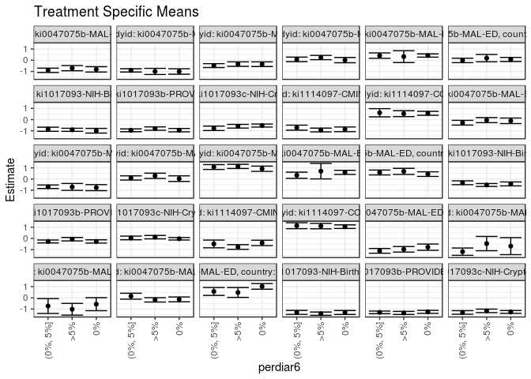

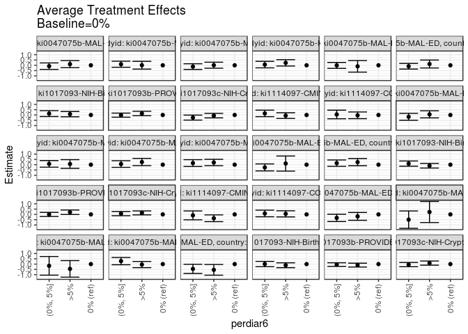

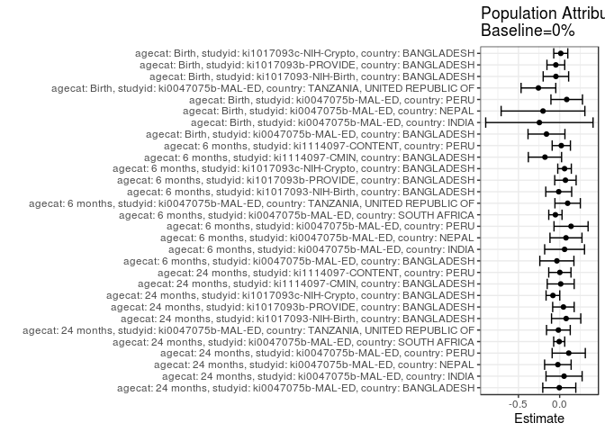

## Results Table

### Parameter: TSM

| agecat | studyid | country | intervention_level | baseline_level | estimate | ci_lower | ci_upper |
| --- | --- | --- | --- | --- | --- | --- | --- |
| Birth | ki0047075b-MAL-ED | BANGLADESH | 0% | NA | -0.7810927 | -1.0619378 | -0.5002476 |
| Birth | ki0047075b-MAL-ED | BANGLADESH | (0%, 5%] | NA | -1.1084660 | -1.3194714 | -0.8974605 |
| Birth | ki0047075b-MAL-ED | BANGLADESH | >5% | NA | -0.9689073 | -1.2154675 | -0.7223472 |
| Birth | ki0047075b-MAL-ED | INDIA | 0% | NA | -0.6862439 | -1.4446605 | 0.0721727 |
| Birth | ki0047075b-MAL-ED | INDIA | (0%, 5%] | NA | -1.1802211 | -1.5063824 | -0.8540599 |
| Birth | ki0047075b-MAL-ED | INDIA | >5% | NA | -0.4604755 | -1.0984328 | 0.1774818 |
| Birth | ki0047075b-MAL-ED | NEPAL | 0% | NA | -0.5662500 | -1.1479485 | 0.0154485 |
| Birth | ki0047075b-MAL-ED | NEPAL | (0%, 5%] | NA | -0.7310000 | -1.3926378 | -0.0693622 |
| Birth | ki0047075b-MAL-ED | NEPAL | >5% | NA | -1.0175000 | -1.5408661 | -0.4941339 |
| Birth | ki0047075b-MAL-ED | PERU | 0% | NA | -0.1372400 | -0.3536700 | 0.0791901 |
| Birth | ki0047075b-MAL-ED | PERU | (0%, 5%] | NA | 0.1453204 | -0.1188031 | 0.4094438 |
| Birth | ki0047075b-MAL-ED | PERU | >5% | NA | -0.1799224 | -0.3717951 | 0.0119503 |
| Birth | ki0047075b-MAL-ED | TANZANIA, UNITED REPUBLIC OF | 0% | NA | 1.0201681 | 0.7705195 | 1.2698166 |
| Birth | ki0047075b-MAL-ED | TANZANIA, UNITED REPUBLIC OF | (0%, 5%] | NA | 0.5681122 | 0.2162973 | 0.9199272 |
| Birth | ki0047075b-MAL-ED | TANZANIA, UNITED REPUBLIC OF | >5% | NA | 0.4780367 | 0.0390725 | 0.9170008 |
| Birth | ki1017093-NIH-Birth | BANGLADESH | 0% | NA | -1.3067626 | -1.4830053 | -1.1305198 |
| Birth | ki1017093-NIH-Birth | BANGLADESH | (0%, 5%] | NA | -1.2986689 | -1.4752753 | -1.1220624 |
| Birth | ki1017093-NIH-Birth | BANGLADESH | >5% | NA | -1.4141809 | -1.5605348 | -1.2678271 |
| Birth | ki1017093b-PROVIDE | BANGLADESH | 0% | NA | -1.2518552 | -1.3832608 | -1.1204497 |
| Birth | ki1017093b-PROVIDE | BANGLADESH | (0%, 5%] | NA | -1.2970987 | -1.4135413 | -1.1806560 |
| Birth | ki1017093b-PROVIDE | BANGLADESH | >5% | NA | -1.3467001 | -1.4819026 | -1.2114976 |
| Birth | ki1017093c-NIH-Crypto | BANGLADESH | 0% | NA | -1.2572986 | -1.3819600 | -1.1326373 |
| Birth | ki1017093c-NIH-Crypto | BANGLADESH | (0%, 5%] | NA | -1.3035866 | -1.4634965 | -1.1436767 |
| Birth | ki1017093c-NIH-Crypto | BANGLADESH | >5% | NA | -1.1616833 | -1.3171398 | -1.0062269 |
| 6 months | ki0047075b-MAL-ED | BANGLADESH | 0% | NA | -0.1043697 | -0.3505152 | 0.1417758 |
| 6 months | ki0047075b-MAL-ED | BANGLADESH | (0%, 5%] | NA | -0.2753378 | -0.4852356 | -0.0654400 |
| 6 months | ki0047075b-MAL-ED | BANGLADESH | >5% | NA | -0.0431686 | -0.2685431 | 0.1822059 |
| 6 months | ki0047075b-MAL-ED | INDIA | 0% | NA | -0.7676456 | -1.0371871 | -0.4981040 |
| 6 months | ki0047075b-MAL-ED | INDIA | (0%, 5%] | NA | -0.6879883 | -0.8446427 | -0.5313340 |
| 6 months | ki0047075b-MAL-ED | INDIA | >5% | NA | -0.7029061 | -1.0114073 | -0.3944050 |

[output cut: 60 more lines]

### Parameter: E(Y)

| agecat | studyid | country | intervention_level | baseline_level | estimate | ci_lower | ci_upper |
| --- | --- | --- | --- | --- | --- | --- | --- |
| Birth | ki0047075b-MAL-ED | BANGLADESH | NA | NA | -0.9412093 | -1.0864308 | -0.7959878 |
| Birth | ki0047075b-MAL-ED | INDIA | NA | NA | -0.9324444 | -1.2067907 | -0.6580982 |
| Birth | ki0047075b-MAL-ED | NEPAL | NA | NA | -0.7684615 | -1.1257770 | -0.4111460 |
| Birth | ki0047075b-MAL-ED | PERU | NA | NA | -0.0520175 | -0.1725298 | 0.0684947 |
| Birth | ki0047075b-MAL-ED | TANZANIA, UNITED REPUBLIC OF | NA | NA | 0.7624348 | 0.5710709 | 0.9537986 |
| Birth | ki1017093-NIH-Birth | BANGLADESH | NA | NA | -1.3525437 | -1.4473932 | -1.2576942 |
| Birth | ki1017093b-PROVIDE | BANGLADESH | NA | NA | -1.2984586 | -1.3752758 | -1.2216415 |
| Birth | ki1017093c-NIH-Crypto | BANGLADESH | NA | NA | -1.2441513 | -1.3281130 | -1.1601897 |
| 6 months | ki0047075b-MAL-ED | BANGLADESH | NA | NA | -0.1383956 | -0.2672708 | -0.0095204 |
| 6 months | ki0047075b-MAL-ED | INDIA | NA | NA | -0.7082698 | -0.8347304 | -0.5818092 |
| 6 months | ki0047075b-MAL-ED | NEPAL | NA | NA | 0.1110452 | -0.0202712 | 0.2423616 |
| 6 months | ki0047075b-MAL-ED | PERU | NA | NA | 1.0568987 | 0.9352990 | 1.1784983 |
| 6 months | ki0047075b-MAL-ED | SOUTH AFRICA | NA | NA | 0.5427231 | 0.3906363 | 0.6948099 |
| 6 months | ki0047075b-MAL-ED | TANZANIA, UNITED REPUBLIC OF | NA | NA | 0.5362213 | 0.4049390 | 0.6675036 |
| 6 months | ki1017093-NIH-Birth | BANGLADESH | NA | NA | -0.4474038 | -0.5378167 | -0.3569909 |
| 6 months | ki1017093b-PROVIDE | BANGLADESH | NA | NA | -0.1990907 | -0.2817968 | -0.1163845 |
| 6 months | ki1017093c-NIH-Crypto | BANGLADESH | NA | NA | 0.0297622 | -0.0491685 | 0.1086930 |
| 6 months | ki1114097-CMIN | BANGLADESH | NA | NA | -0.5780453 | -0.7226627 | -0.4334279 |
| 6 months | ki1114097-CONTENT | PERU | NA | NA | 1.0684318 | 0.9515274 | 1.1853362 |
| 24 months | ki0047075b-MAL-ED | BANGLADESH | NA | NA | -0.8201887 | -0.9423967 | -0.6979806 |
| 24 months | ki0047075b-MAL-ED | INDIA | NA | NA | -0.9522907 | -1.0676596 | -0.8369219 |
| 24 months | ki0047075b-MAL-ED | NEPAL | NA | NA | -0.3764474 | -0.4898516 | -0.2630431 |
| 24 months | ki0047075b-MAL-ED | PERU | NA | NA | 0.1204478 | 0.0005049 | 0.2403906 |
| 24 months | ki0047075b-MAL-ED | SOUTH AFRICA | NA | NA | 0.4148529 | 0.2940577 | 0.5356481 |
| 24 months | ki0047075b-MAL-ED | TANZANIA, UNITED REPUBLIC OF | NA | NA | 0.0539486 | -0.0712465 | 0.1791437 |
| 24 months | ki1017093-NIH-Birth | BANGLADESH | NA | NA | -0.9115790 | -1.0095022 | -0.8136559 |
| 24 months | ki1017093b-PROVIDE | BANGLADESH | NA | NA | -0.8928670 | -0.9755153 | -0.8102187 |
| 24 months | ki1017093c-NIH-Crypto | BANGLADESH | NA | NA | -0.6103502 | -0.7050157 | -0.5156847 |
| 24 months | ki1114097-CMIN | BANGLADESH | NA | NA | -0.8535391 | -0.9644236 | -0.7426546 |
| 24 months | ki1114097-CONTENT | PERU | NA | NA | 0.5668293 | 0.4302437 | 0.7034148 |

### Parameter: ATE

| agecat | studyid | country | intervention_level | baseline_level | estimate | ci_lower | ci_upper |
| --- | --- | --- | --- | --- | --- | --- | --- |
| Birth | ki0047075b-MAL-ED | BANGLADESH | 0% | 0% | 0.0000000 | 0.0000000 | 0.0000000 |
| Birth | ki0047075b-MAL-ED | BANGLADESH | (0%, 5%] | 0% | -0.3273733 | -0.6712845 | 0.0165380 |
| Birth | ki0047075b-MAL-ED | BANGLADESH | >5% | 0% | -0.1878147 | -0.5578542 | 0.1822249 |
| Birth | ki0047075b-MAL-ED | INDIA | 0% | 0% | 0.0000000 | 0.0000000 | 0.0000000 |
| Birth | ki0047075b-MAL-ED | INDIA | (0%, 5%] | 0% | -0.4939772 | -1.3140741 | 0.3261197 |
| Birth | ki0047075b-MAL-ED | INDIA | >5% | 0% | 0.2257684 | -0.7701858 | 1.2217226 |
| Birth | ki0047075b-MAL-ED | NEPAL | 0% | 0% | 0.0000000 | 0.0000000 | 0.0000000 |
| Birth | ki0047075b-MAL-ED | NEPAL | (0%, 5%] | 0% | -0.1647500 | -1.0457368 | 0.7162368 |
| Birth | ki0047075b-MAL-ED | NEPAL | >5% | 0% | -0.4512500 | -1.2337366 | 0.3312366 |
| Birth | ki0047075b-MAL-ED | PERU | 0% | 0% | 0.0000000 | 0.0000000 | 0.0000000 |
| Birth | ki0047075b-MAL-ED | PERU | (0%, 5%] | 0% | 0.2825603 | -0.0599234 | 0.6250441 |
| Birth | ki0047075b-MAL-ED | PERU | >5% | 0% | -0.0426824 | -0.3332910 | 0.2479261 |
| Birth | ki0047075b-MAL-ED | TANZANIA, UNITED REPUBLIC OF | 0% | 0% | 0.0000000 | 0.0000000 | 0.0000000 |
| Birth | ki0047075b-MAL-ED | TANZANIA, UNITED REPUBLIC OF | (0%, 5%] | 0% | -0.4520558 | -0.8843958 | -0.0197159 |
| Birth | ki0047075b-MAL-ED | TANZANIA, UNITED REPUBLIC OF | >5% | 0% | -0.5421314 | -1.0478329 | -0.0364299 |
| Birth | ki1017093-NIH-Birth | BANGLADESH | 0% | 0% | 0.0000000 | 0.0000000 | 0.0000000 |
| Birth | ki1017093-NIH-Birth | BANGLADESH | (0%, 5%] | 0% | 0.0080937 | -0.2413665 | 0.2575538 |
| Birth | ki1017093-NIH-Birth | BANGLADESH | >5% | 0% | -0.1074184 | -0.3364564 | 0.1216197 |
| Birth | ki1017093b-PROVIDE | BANGLADESH | 0% | 0% | 0.0000000 | 0.0000000 | 0.0000000 |
| Birth | ki1017093b-PROVIDE | BANGLADESH | (0%, 5%] | 0% | -0.0452435 | -0.2157030 | 0.1252161 |
| Birth | ki1017093b-PROVIDE | BANGLADESH | >5% | 0% | -0.0948449 | -0.2784616 | 0.0887718 |
| Birth | ki1017093c-NIH-Crypto | BANGLADESH | 0% | 0% | 0.0000000 | 0.0000000 | 0.0000000 |
| Birth | ki1017093c-NIH-Crypto | BANGLADESH | (0%, 5%] | 0% | -0.0462880 | -0.2455270 | 0.1529510 |
| Birth | ki1017093c-NIH-Crypto | BANGLADESH | >5% | 0% | 0.0956153 | -0.1001062 | 0.2913368 |
| 6 months | ki0047075b-MAL-ED | BANGLADESH | 0% | 0% | 0.0000000 | 0.0000000 | 0.0000000 |
| 6 months | ki0047075b-MAL-ED | BANGLADESH | (0%, 5%] | 0% | -0.1709681 | -0.4952260 | 0.1532897 |
| 6 months | ki0047075b-MAL-ED | BANGLADESH | >5% | 0% | 0.0612011 | -0.2731548 | 0.3955570 |
| 6 months | ki0047075b-MAL-ED | INDIA | 0% | 0% | 0.0000000 | 0.0000000 | 0.0000000 |
| 6 months | ki0047075b-MAL-ED | INDIA | (0%, 5%] | 0% | 0.0796572 | -0.2321612 | 0.3914756 |
| 6 months | ki0047075b-MAL-ED | INDIA | >5% | 0% | 0.0647394 | -0.3452396 | 0.4747185 |

[output cut: 60 more lines]

### Parameter: PAR

| agecat | studyid | country | intervention_level | baseline_level | estimate | ci_lower | ci_upper |
| --- | --- | --- | --- | --- | --- | --- | --- |
| Birth | ki0047075b-MAL-ED | BANGLADESH | 0% | NA | -0.1601166 | -0.3838706 | 0.0636374 |
| Birth | ki0047075b-MAL-ED | INDIA | 0% | NA | -0.2462005 | -0.8971039 | 0.4047029 |
| Birth | ki0047075b-MAL-ED | NEPAL | 0% | NA | -0.2022115 | -0.7099692 | 0.3055462 |
| Birth | ki0047075b-MAL-ED | PERU | 0% | NA | 0.0852224 | -0.1059681 | 0.2764129 |
| Birth | ki0047075b-MAL-ED | TANZANIA, UNITED REPUBLIC OF | 0% | NA | -0.2577333 | -0.4681618 | -0.0473047 |
| Birth | ki1017093-NIH-Birth | BANGLADESH | 0% | NA | -0.0457812 | -0.2001893 | 0.1086270 |
| Birth | ki1017093b-PROVIDE | BANGLADESH | 0% | NA | -0.0466034 | -0.1543837 | 0.0611769 |
| Birth | ki1017093c-NIH-Crypto | BANGLADESH | 0% | NA | 0.0131473 | -0.0720036 | 0.0982982 |
| 6 months | ki0047075b-MAL-ED | BANGLADESH | 0% | NA | -0.0340259 | -0.2407480 | 0.1726963 |
| 6 months | ki0047075b-MAL-ED | INDIA | 0% | NA | 0.0593758 | -0.1822540 | 0.3010055 |
| 6 months | ki0047075b-MAL-ED | NEPAL | 0% | NA | 0.0764353 | -0.1175692 | 0.2704399 |
| 6 months | ki0047075b-MAL-ED | PERU | 0% | NA | 0.1378954 | -0.0687573 | 0.3445480 |
| 6 months | ki0047075b-MAL-ED | SOUTH AFRICA | 0% | NA | -0.0519611 | -0.1323959 | 0.0284737 |
| 6 months | ki0047075b-MAL-ED | TANZANIA, UNITED REPUBLIC OF | 0% | NA | 0.0964669 | -0.0576170 | 0.2505509 |
| 6 months | ki1017093-NIH-Birth | BANGLADESH | 0% | NA | -0.0115935 | -0.1686181 | 0.1454311 |
| 6 months | ki1017093b-PROVIDE | BANGLADESH | 0% | NA | 0.0696838 | -0.0601102 | 0.1994778 |
| 6 months | ki1017093c-NIH-Crypto | BANGLADESH | 0% | NA | 0.0590153 | -0.0232310 | 0.1412617 |
| 6 months | ki1114097-CMIN | BANGLADESH | 0% | NA | -0.1785228 | -0.3801797 | 0.0231342 |
| 6 months | ki1114097-CONTENT | PERU | 0% | NA | 0.0195926 | -0.0911175 | 0.1303026 |
| 24 months | ki0047075b-MAL-ED | BANGLADESH | 0% | NA | -0.0048107 | -0.2050337 | 0.1954124 |
| 24 months | ki0047075b-MAL-ED | INDIA | 0% | NA | 0.0532560 | -0.1657357 | 0.2722477 |
| 24 months | ki0047075b-MAL-ED | NEPAL | 0% | NA | -0.0220303 | -0.1828200 | 0.1387595 |
| 24 months | ki0047075b-MAL-ED | PERU | 0% | NA | 0.1097555 | -0.0913547 | 0.3108658 |
| 24 months | ki0047075b-MAL-ED | SOUTH AFRICA | 0% | NA | -0.0057968 | -0.0728277 | 0.0612342 |
| 24 months | ki0047075b-MAL-ED | TANZANIA, UNITED REPUBLIC OF | 0% | NA | -0.0157623 | -0.1596367 | 0.1281120 |
| 24 months | ki1017093-NIH-Birth | BANGLADESH | 0% | NA | 0.0785188 | -0.0987628 | 0.2558003 |
| 24 months | ki1017093b-PROVIDE | BANGLADESH | 0% | NA | 0.0453564 | -0.0849267 | 0.1756395 |
| 24 months | ki1017093c-NIH-Crypto | BANGLADESH | 0% | NA | -0.0820308 | -0.1650323 | 0.0009707 |
| 24 months | ki1114097-CMIN | BANGLADESH | 0% | NA | 0.0124106 | -0.1510906 | 0.1759117 |
| 24 months | ki1114097-CONTENT | PERU | 0% | NA | 0.0021239 | -0.1326827 | 0.1369305 |